# ESM 244 Lab 4 Part 1: Spatial point pattern analysis

Author

Casey O’Hara, Nathan Grimes, Allison Horst

Published

February 1, 2024

See: - CRS & proj4 components breakdown: https://www.earthdatascience.org/courses/earth-analytics/spatial-data-r/reproject-vector-data/

```r
library(spatstat)
library(terra)
library(tidyverse)
library(here)
library(sf)
library(tmap)
```

This is an example of point pattern analysis with a density plot, and the G- & L- function (distance methods) to compare our observed points with simulated complete spatial randomness.

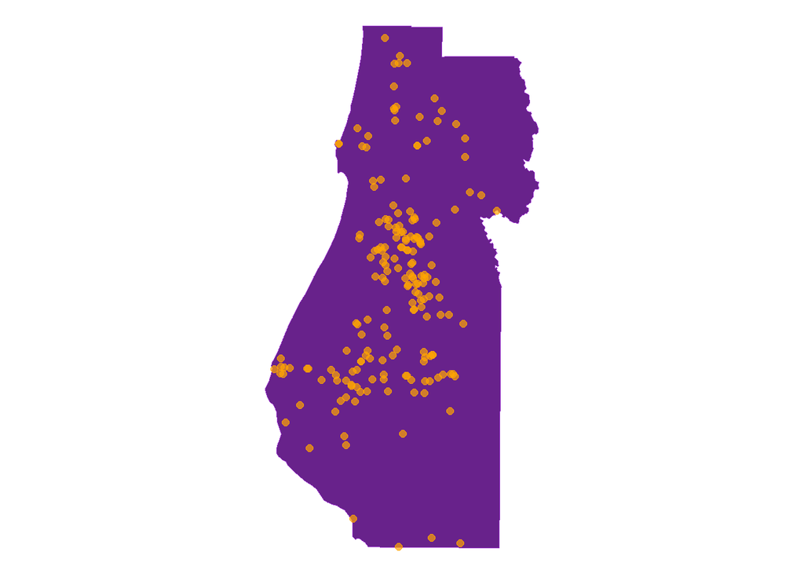

```r
### Read in the tree vole data
voles_sf <- read_sf(dsn = here("data/voledata"),
                    layer = "ds033") %>%
  janitor::clean_names() %>%
  select(county) %>%      ### Only select the county attribute; geometry sticks
  filter(county == "HUM") ### Only keep observations in Humboldt County


### Plot it (exploratory)
# plot(voles_sf)

### Get Humboldt County outline
humboldt_sf <- read_sf(dsn = here("data/voledata"),
                    layer = "ca_counties") %>%
  janitor::clean_names() %>%
  filter(name == "Humboldt") %>% # Isolate Humboldt County
  select(name) %>% ### Only keep one attribute (name) to simplify
  st_transform(crs = st_crs(voles_sf))


### plot them together
ggplot() +
  geom_sf(data = humboldt_sf,
          color = "darkorchid",
          fill = "darkorchid4",
          size = 1) +
  geom_sf(data = voles_sf,
          color = "orange",
          alpha = 0.7,
          size = 2) +
  theme_void()
```

These need to be combined into spatial point pattern data (points + window combo), and for point pattern analysis this **requires a 2D projection** (in this case, UTM), which is why we used the voles data CRS (UTM projection) instead of the county data CRS (unprojected lat-long). This looks quite a bit different from what we’ve done so far - it uses functions in `spatstat` to create point patterns that play nicely with other functions for data viz & point pattern analysis.

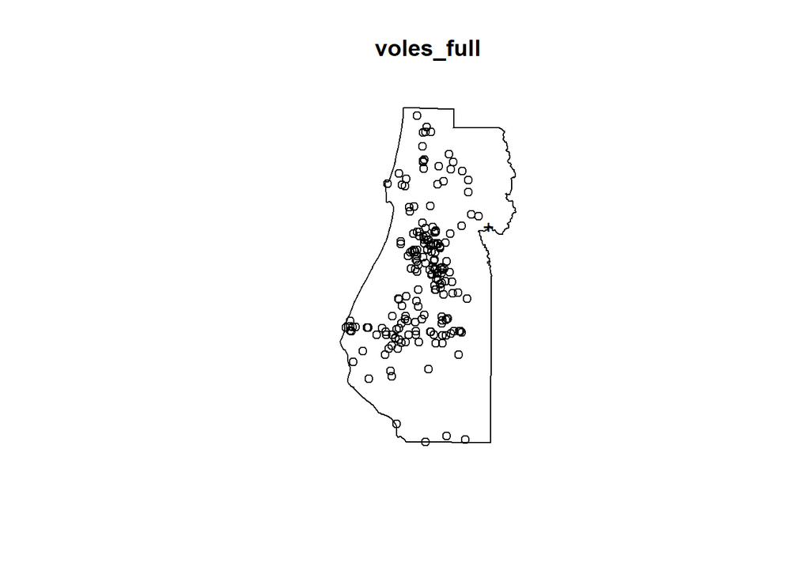

```r
### Convert vole observations to spatial point pattern
voles_ppp <- as.ppp(voles_sf)

### Convert county boundary to observation window
humboldt_win <- as.owin(humboldt_sf)

### Combine as a point pattern object (points + window):
voles_full <- ppp(voles_ppp$x, voles_ppp$y, window = humboldt_win)

plot(voles_full)
```

```r
### Illegal point (outside window) shows up as the plus sign
```

## 1 Make a kernel density plot:

### 1.1 Density

Run to see vole “hotspots” by kernel density, then see what happens when you change sigma here!

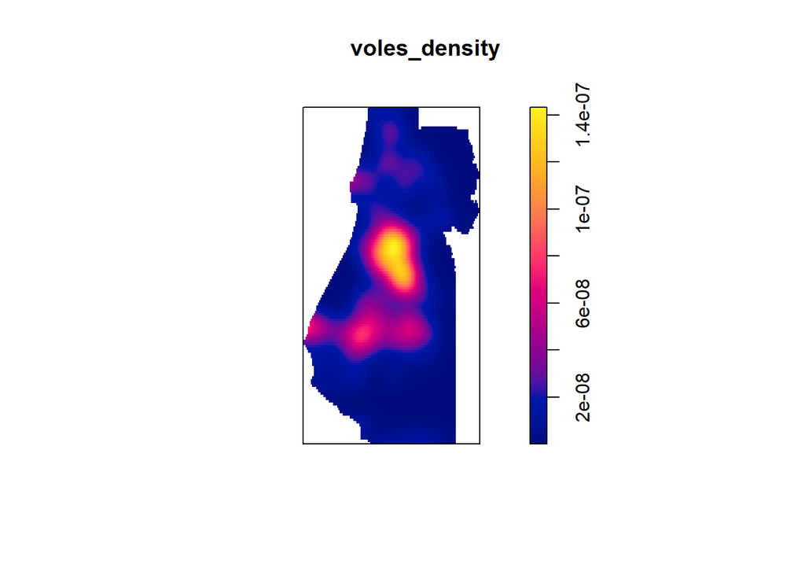

```r
voles_density <- density(voles_full, sigma = 5000) ### try different sigmas

plot(voles_density)
```

Pretty clear that there are “hotspots” where voles are observed - both in the originally plotted data and in the density plot. How can we compare this to complete spatial randomness?

```r
### Can you start viewing this in tmap? Yes, rasterize it:
vole_r <- rast(voles_density)
crs(vole_r) <- crs(voles_sf)

### Then plot:
tmap_mode("view")

tm_shape(vole_r) +
  tm_raster(palette = "Reds",
            legend.show = FALSE)
```

## 2 Nearest neighbor (G-function)

In this week’s lecture, we learned about distance methods to compare our point pattern to a scenario of complete spatial randomness. Here, we’ll use both the G- and L-functions (L function is the K-function, standardized…interpretation is the same) to compare our observed point pattern to a simulated CSR scenario, to help us determine if it is *more clustered* or *more uniform* than CSR.

What is going on in this code?

```r
### Make a sequence of distances over which you'll calculate G(r)
r_vec <- seq(0, 10000, by = 100)

gfunction_out <- envelope(voles_full, fun = Gest, r = r_vec,
                          nsim = 100)
```

```
Generating 100 simulations of CSR  ...
1, 2, 3, 4, 5, 6, 7, 8, 9, 10, 11, 12, 13, 14, 15, 16, 17, 18, 19, 20,
21, 22, 23, 24, 25, 26, 27, 28, 29, 30, 31, 32, 33, 34, 35, 36, 37, 38, 39, 40,
41, 42, 43, 44, 45, 46, 47, 48, 49, 50, 51, 52, 53, 54, 55, 56, 57, 58, 59, 60,
61, 62, 63, 64, 65, 66, 67, 68, 69, 70, 71, 72, 73, 74, 75, 76, 77, 78, 79, 80,
81, 82, 83, 84, 85, 86, 87, 88, 89, 90, 91, 92, 93, 94, 95, 96, 97, 98, 99,
100.

Done.
```

```r
### Calculate the actual and theoretical G(r) values, using 100
### simulations of CSR for the "theoretical" outcome

gfunction_out ### Check the output of gfunction, then...
```

```
Pointwise critical envelopes for G(r)
and observed value for 'voles_full'
Edge correction: "km"
Obtained from 100 simulations of CSR
Alternative: two.sided
Significance level of pointwise Monte Carlo test: 2/101 = 0.0198
.....................................................................
     Math.label     Description
r    r              distance argument r
obs  hat(G)[obs](r) observed value of G(r) for data pattern
theo G[theo](r)     theoretical value of G(r) for CSR
lo   hat(G)[lo](r)  lower pointwise envelope of G(r) from simulations
hi   hat(G)[hi](r)  upper pointwise envelope of G(r) from simulations
.....................................................................
Default plot formula:  .~r
where "." stands for 'obs', 'theo', 'hi', 'lo'
Columns 'lo' and 'hi' will be plotted as shading (by default)
Recommended range of argument r: [0, 4400]
Available range of argument r: [0, 10000]
```

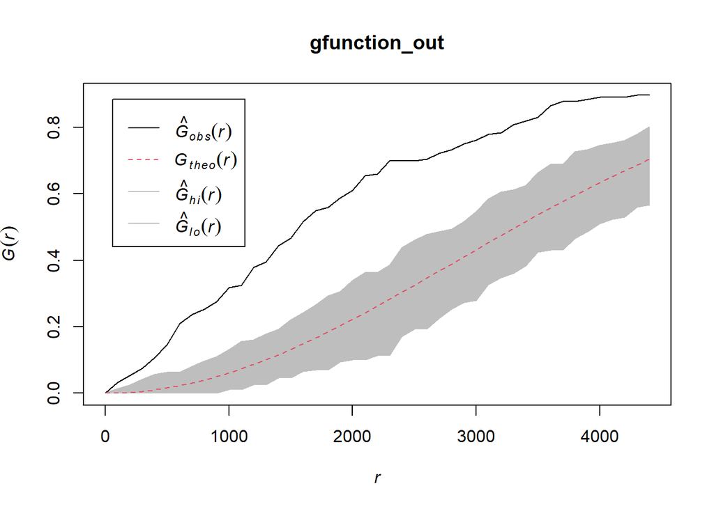

```r
plot(gfunction_out)
```

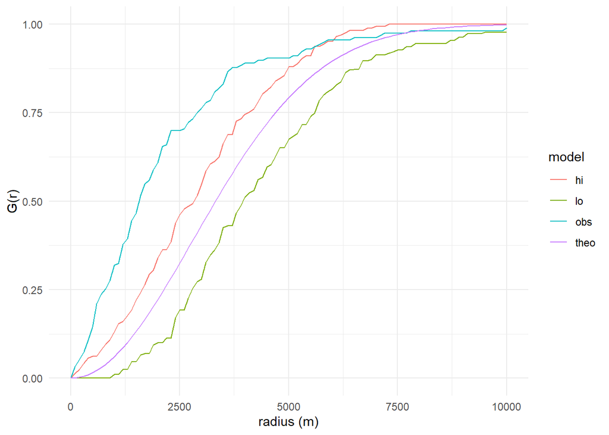

```r
### Gather this to plot series in ggplot:
gfunction_long <- gfunction_out %>%
  as.data.frame() %>%
  pivot_longer(cols = obs:hi, names_to = "model", values_to = "g_val")

### Then make a graph in ggplot:
ggplot(data = gfunction_long, aes(x = r, y = g_val, group = model)) +
  geom_line(aes(color = model)) +
  theme_minimal() +
  labs(x = 'radius (m)', y = 'G(r)')
```

This again confirms clustering - our data (model = obs) has a greater proportion of events with nearest neighbor at *smaller distances* compared to a theoretical CSR scenario (model = theo). But remember, the G-function only considers the single nearest neighbor.

Let’s similarly look at the L-function (standardized Ripley’s K-function) which considers densities of observations within some distance R (expanding circles around each point) for comparison. This is using very similar code, but now the function is `Lest` for “L estimate”, which calculates the density of events within growing circles around *each point*. That is much more intensive than just the single nearest neighbor, so I run `nsim = 10` here instead (you can do 100 or more again, you’ll just notice that creating the simulations takes longer).

For a completely random (uniform Poisson) point pattern, the theoretical value of the L-function is L(r) = r.

```r
r_vec2 <- seq(0, 80000, by = 5000)

lfunction_out <- envelope(voles_full, fun = Lest, r = r_vec2,
                          nsim = 10)
```

```
Generating 10 simulations of CSR  ...
1, 2, 3, 4, 5, 6, 7, 8, 9,
10.

Done.
```

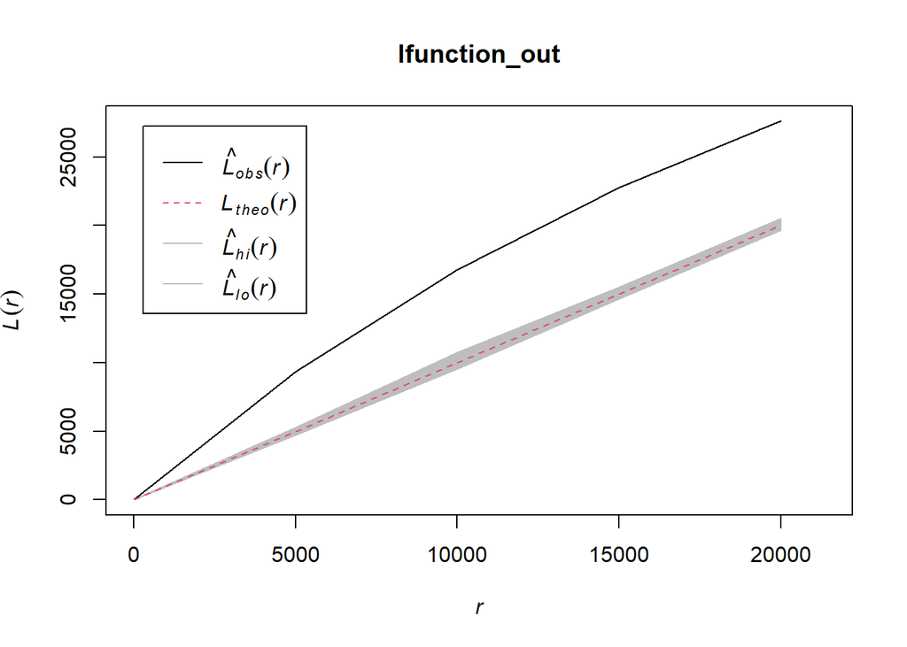

```r
plot(lfunction_out)
```

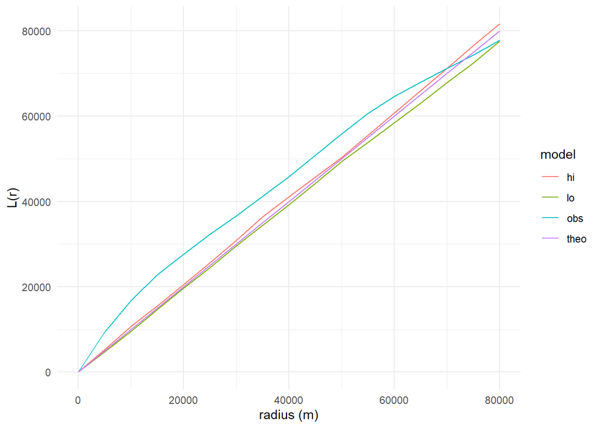

```r
### STUDENTS DO: Gather this to plot series in ggplot:
lfunction_long <- lfunction_out %>%
  as.data.frame() %>%
  pivot_longer(cols = obs:hi, names_to = "model", values_to = "l")

ggplot(data = lfunction_long, aes(x = r, y = l, group = model)) +
  geom_line(aes(color = model)) +
  theme_minimal() +
  labs(x = 'radius (m)', y = 'L(r)')
```

We again see that at lower distances, our data overall has a higher density of nearest neighbors compared to a simulated CSR scenario. Again, evidence of clustering.